# R Notebook

```r
prelim_results <- prelim_results %>%
  mutate(across(c(awake_hour, awake_min, rem_hour, rem_min, light_hour, light_min, deep_hour, deep_min), ~replace_na(., 0))) %>%
  mutate(AwakeNumHour = awake_hour + (awake_min / 60)) %>%
  relocate(AwakeNumHour, .after = awake_min) %>%
  mutate(REMNumHour = rem_hour + (rem_min / 60)) %>%
  relocate(REMNumHour, .after = rem_min) %>%
  mutate(LightNumHour = light_hour + (light_min / 60)) %>%
  relocate(LightNumHour, .after = light_min) %>%
  mutate(DeepNumHour = deep_hour + (deep_min / 60)) %>%
  relocate(DeepNumHour, .after = deep_min) %>%
  mutate(TotalNumHour = AwakeNumHour + REMNumHour + LightNumHour + DeepNumHour) %>%
  relocate(TotalNumHour, .after = DeepNumHour)
```

```r
prelim_results <- prelim_results %>%
  group_by(name) %>%
  mutate(participant_id = cur_group_id()) %>%
  ungroup() %>%
  relocate(participant_id, .after = name)

participants_to_exclude <- c("Clarissa Yang", "Zhigui Lee", "Neal Hughes", "Jessica Chen", "DROP")
prelim_results <- prelim_results %>%
  filter(!name %in% participants_to_exclude)
```

```r
# fit the linear mixed-effects model to deep sleep hours
model1 <- lmer(DeepNumHour ~ steps + (1 | name), data = prelim_results )
summary(model1)
```

```
Linear mixed model fit by REML ['lmerMod']
Formula: DeepNumHour ~ steps + (1 | name)
   Data: prelim_results

REML criterion at convergence: 253.3

Scaled residuals:
    Min      1Q  Median      3Q     Max
-2.6367 -0.5570 -0.0648  0.3883  4.1373

Random effects:
 Groups   Name        Variance Std.Dev.
 name     (Intercept) 0.2199   0.4689
 Residual             0.1975   0.4444
Number of obs: 160, groups:  name, 15

Fixed effects:
             Estimate Std. Error t value
(Intercept) 1.066e+00  1.482e-01   7.192
steps       1.357e-05  1.038e-05   1.307

Correlation of Fixed Effects:
      (Intr)
steps -0.514
fit warnings:
Some predictor variables are on very different scales: consider rescaling
```

```r
# fit the linear mixed-effects model to overall sleep hours
model2 <- lmer(TotalNumHour ~ steps + (1 | name), data = prelim_results)
summary(model2)
```

```
Linear mixed model fit by REML ['lmerMod']
Formula: TotalNumHour ~ steps + (1 | name)
   Data: prelim_results

REML criterion at convergence: 532

Scaled residuals:
    Min      1Q  Median      3Q     Max
-2.5570 -0.6687  0.1178  0.5140  4.0022

Random effects:
 Groups   Name        Variance Std.Dev.
 name     (Intercept) 0.6563   0.8101
 Residual             1.2185   1.1039
Number of obs: 160, groups:  name, 15

Fixed effects:
             Estimate Std. Error t value
(Intercept) 7.589e+00  2.958e-01  25.659
steps       2.318e-05  2.533e-05   0.915

Correlation of Fixed Effects:
      (Intr)
steps -0.631
fit warnings:
Some predictor variables are on very different scales: consider rescaling
```

```r
# correlation
cor_results <- prelim_results %>%
  select(steps, TotalNumHour, DeepNumHour) %>%
  cor(use = "complete.obs")

print(cor_results)
```

```
                  steps TotalNumHour DeepNumHour
steps        1.00000000    0.1771056  0.03332534
TotalNumHour 0.17710564    1.0000000  0.22676382
DeepNumHour  0.03332534    0.2267638  1.00000000
```

```r
# multiple linreg
model3 <- lm(DeepNumHour ~ steps, data = prelim_results)
cat("multiple linear regression on number of step count and deep sleep hours- unclustered individual")
```

```
multiple linear regression on number of step count and deep sleep hours- unclustered individual
```

```r
summary(model3)
```

```
Call:
lm(formula = DeepNumHour ~ steps, data = prelim_results)

Residuals:
    Min      1Q  Median      3Q     Max
-1.0591 -0.4511 -0.1391  0.3688  2.3980

Coefficients:
             Estimate Std. Error t value Pr(>|t|)
(Intercept) 1.095e+00  1.048e-01  10.451   <2e-16 ***
steps       5.064e-06  1.208e-05   0.419    0.676
---
Signif. codes:  0 '***' 0.001 '**' 0.01 '*' 0.05 '.' 0.1 ' ' 1

Residual standard error: 0.6352 on 158 degrees of freedom
Multiple R-squared:  0.001111,  Adjusted R-squared:  -0.005212
F-statistic: 0.1757 on 1 and 158 DF,  p-value: 0.6757
```

```r
# ANOVA
anova_results <- aov(DeepNumHour ~ steps, data = prelim_results)
cat("ANOVA to look at number of step count deep sleep hours- unclustered individual")
```

```
ANOVA to look at number of step count deep sleep hours- unclustered individual
```

```r
summary(anova_results)
```

```
             Df Sum Sq Mean Sq F value Pr(>F)
steps         1   0.07  0.0709   0.176  0.676
Residuals   158  63.75  0.4035
```

```r
# linear mixed effects, with interaction
model4 <- lmer(DeepNumHour ~ steps * TotalNumHour + (1 | name), data = prelim_results)
summary(model4)
```

```
Linear mixed model fit by REML ['lmerMod']
Formula: DeepNumHour ~ steps * TotalNumHour + (1 | name)
   Data: prelim_results

REML criterion at convergence: 275.6

Scaled residuals:
    Min      1Q  Median      3Q     Max
-2.4945 -0.5819 -0.0543  0.4039  4.3083

Random effects:
 Groups   Name        Variance Std.Dev.
 name     (Intercept) 0.2093   0.4574
 Residual             0.1947   0.4412
Number of obs: 160, groups:  name, 15

Fixed effects:
                     Estimate Std. Error t value
(Intercept)         2.565e-01  4.865e-01   0.527
steps               5.335e-05  5.376e-05   0.992
TotalNumHour        1.053e-01  5.996e-02   1.756
steps:TotalNumHour -5.168e-06  6.646e-06  -0.778

Correlation of Fixed Effects:
            (Intr) steps  TtlNmH
steps       -0.816
TotalNumHor -0.954  0.819
stps:TtlNmH  0.807 -0.981 -0.841
fit warnings:
Some predictor variables are on very different scales: consider rescaling
```

Linear mixed-effects with interaction: The model includes interaction terms to see if the relationship between steps and DeepNumHour changes at different levels of TotalNumHour. The coefficients for steps, TotalNumHour, and their interaction are not statistically significant, meaning there is no significant relationship between these variables and DeepNumHour.

#Below is for poster graphing

``` r descriptive_stats <- prelim_results %>% summarise( Mean_Steps = mean(steps, na.rm = TRUE), SD_Steps = sd(steps, na.rm = TRUE), Min_Steps = min(steps, na.rm = TRUE), Max_Steps = max(steps, na.rm = TRUE), Mean_DeepNumHour = mean(DeepNumHour, na.rm = TRUE), SD_DeepNumHour = sd(DeepNumHour, na.rm = TRUE), Min_DeepNumHour = min(DeepNumHour, na.rm = TRUE), Max_DeepNumHour = max(DeepNumHour, na.rm = TRUE) )

print(descriptive_stats) ```

`# A tibble: 1 × 8 Mean_Steps SD_Steps Min_Steps Max_Steps Mean_DeepNumHour SD_DeepNumHour <dbl> <dbl> <int> <int> <dbl> <dbl> 1 7614. 4169. 5 21218 1.13 0.634 # ℹ 2 more variables: Min_DeepNumHour <dbl>, Max_DeepNumHour <dbl>`

``` r group_stats <- prelim_results %>% group_by(study_week) %>% summarise( Mean_Steps = mean(steps, na.rm = TRUE), SD_Steps = sd(steps, na.rm = TRUE), Mean_DeepNumHour = mean(DeepNumHour, na.rm = TRUE), SD_DeepNumHour = sd(DeepNumHour, na.rm = TRUE), Count = n() )

print(group_stats) ```

`# A tibble: 2 × 6 study_week Mean_Steps SD_Steps Mean_DeepNumHour SD_DeepNumHour Count <int> <dbl> <dbl> <dbl> <dbl> <int> 1 1 7217. 3718. 1.14 0.606 86 2 2 8075. 4622. 1.13 0.669 74`

`r # histogram of Steps ggplot(prelim_results, aes(x = steps)) + geom_histogram(binwidth = 1000, fill = "skyblue", color = "black") + labs(title = "Distribution of Steps", x = "Number of Steps", y = "Frequency") + theme_minimal()`

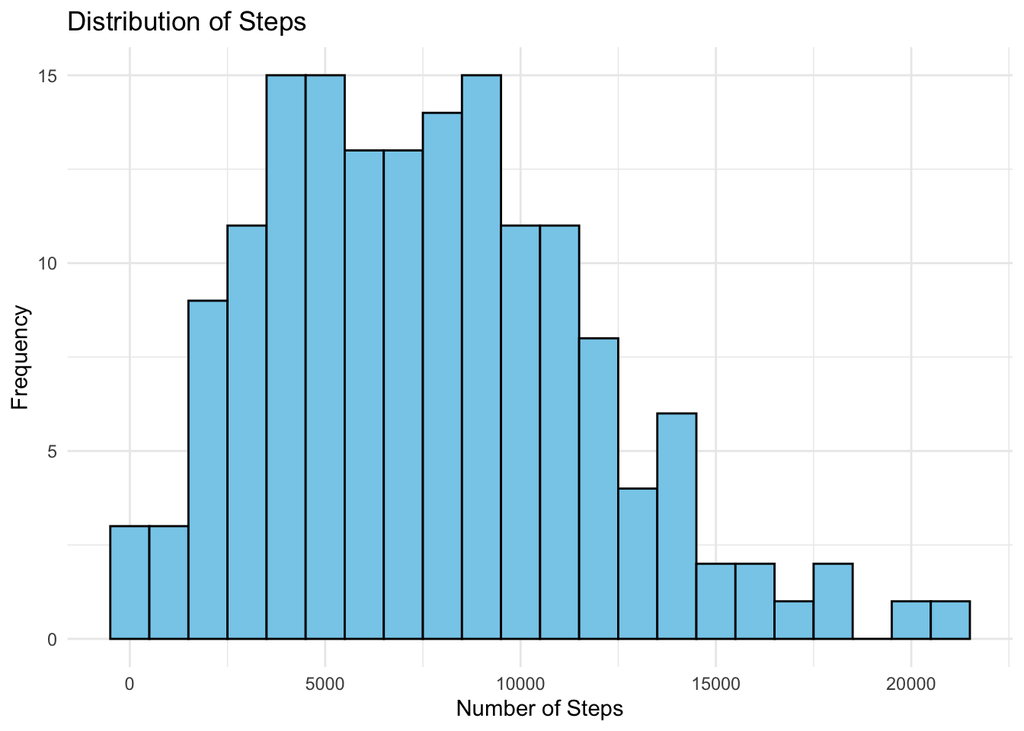

`r # density plot- deep sleep hours ggplot(prelim_results, aes(x = DeepNumHour)) + geom_density(fill = "skyblue") + labs(title = "Density of Deep Sleep Hours", x = "Deep Sleep Hours", y = "Density") + theme_minimal()`

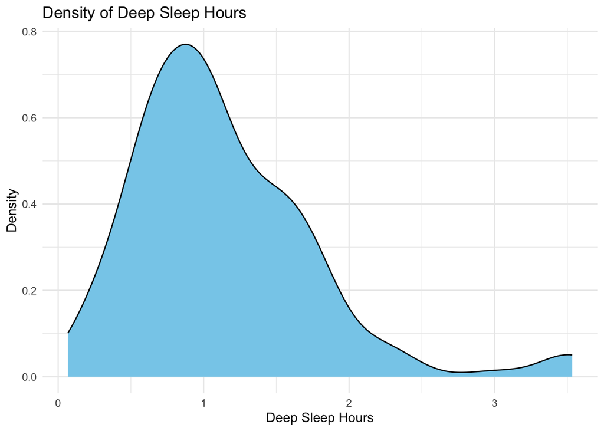

`r ggplot(prelim_results, aes(x = REMNumHour)) + geom_density(fill = "skyblue") + labs(title = "Density of REM Sleep Hours", x = "REM Sleep Hours", y = "Density") + theme_minimal()`

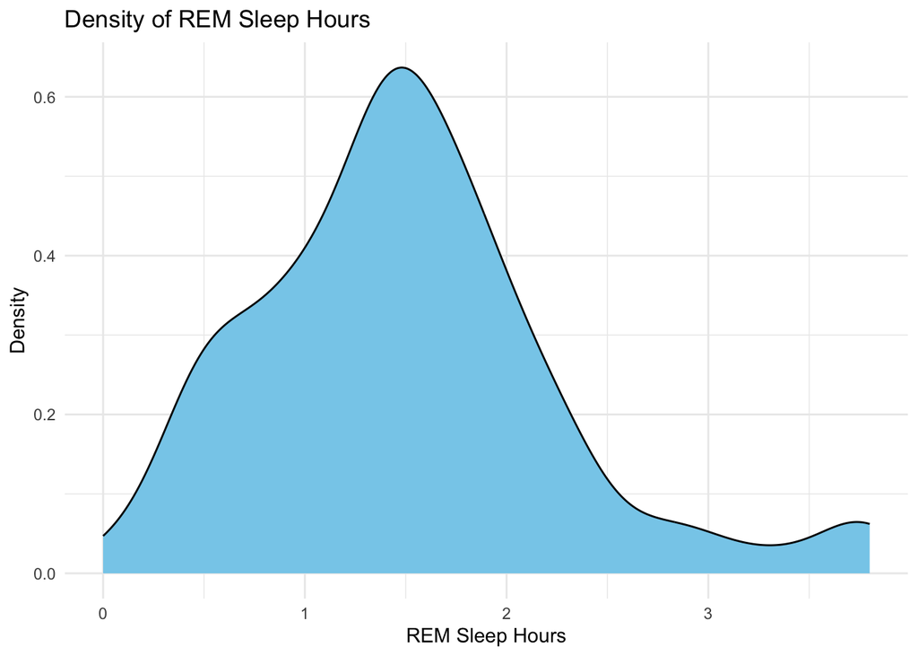

`r ggplot(prelim_results, aes(x = LightNumHour)) + geom_density(fill = "skyblue") + labs(title = "Density of Core/Light Sleep Hours", x = "Core/Light Sleep Hours", y = "Density") + theme_minimal()`

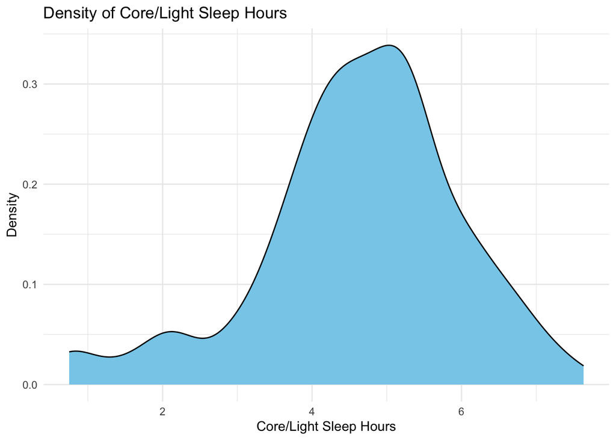

`r ggplot(prelim_results, aes(x = AwakeNumHour)) + geom_density(fill = "skyblue") + labs(title = "Density of Awake Hours", x = "Awake Hours", y = "Density") + theme_minimal()`

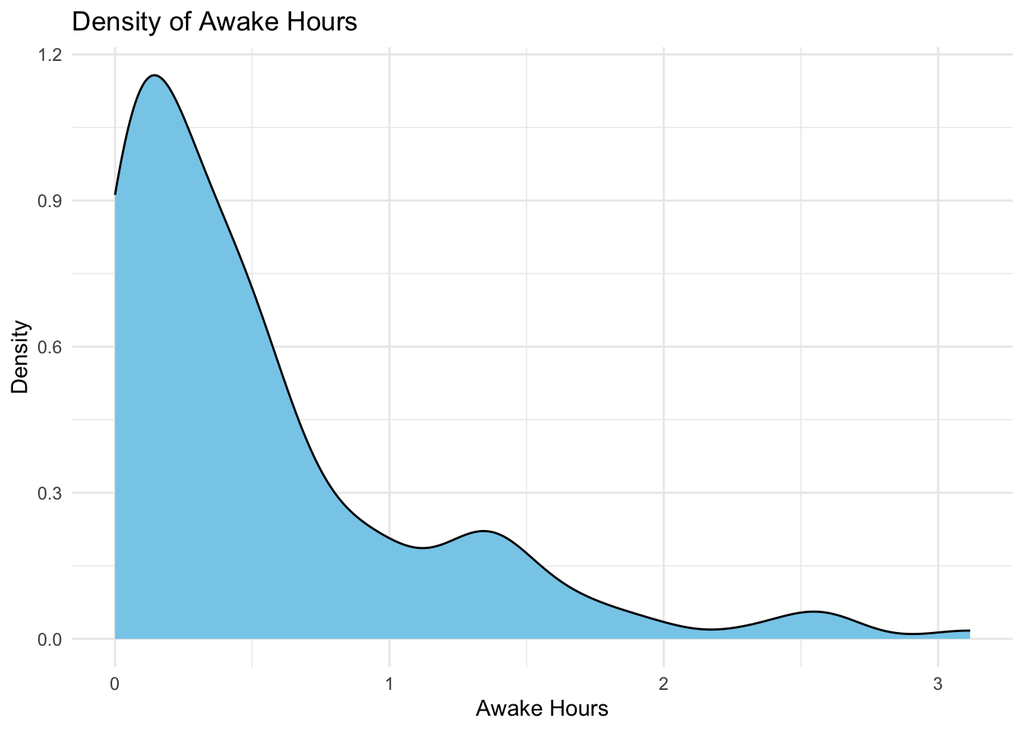

``` r prelim_results$Date <- as.Date(prelim_results$activity_sleep_date, format = “%m/%d/%y”)

# steps line plot participants_to_exclude <- c(“Clarissa Yang”, “Zhigui Lee”, “Neal Hughes”, “Jessica Chen”, “DROP”) prelim_results <- prelim_results %>% filter(!name %in% participants_to_exclude) ggplot(prelim_results, aes(x = Date, y = steps, group = treatment, color = treatment)) + geom_point() + geom_smooth(method = “lm”, se = FALSE) + labs(title = “Steps Over Time, Faceted by Treatment Week”, x = “Date”, y = “Step count”) + facet_wrap(~ study_week, scales = “free_y”) + theme(legend.position = “bottom”) + theme_minimal() + theme(legend.position = “bottom”) ```